# StockMarketPrediction_PCA

**MEAN ABSOLUTE ERROR (MAE) FOR TEST DATA**

```python
from sklearn.metrics import mean_absolute_error
print("MEAN ABSOLUTE ERROR (MAE) FOR TEST DATA IS")
np.round(mean_absolute_error(y_pred,y_test),3)
```

```
MEAN ABSOLUTE ERROR (MAE) FOR TEST DATA IS
```

```
5.305
```

**MEAN SQUARE ERROR (MSE) FOR TEST DATA**

```python
from sklearn.metrics import mean_squared_error
print("MEAN SQUARE ERROR (MSE) FOR TEST DATA IS")
mse=np.round(mean_squared_error(y_pred,y_test),3)
mse
```

```
MEAN SQUARE ERROR (MSE) FOR TEST DATA IS
```

```
64.241
```

**ROOT MEAN SQUARE ERROR (MSE) FOR TEST DATA**

```python
import math
math.sqrt(mse)
```

```
8.015048346703843
```

**MEDIAN ABSOLUTE ERROR (MAE) FOR TEST DATA**

```python
from sklearn.metrics import median_absolute_error
print("MEDIAN ABSOLUTE ERROR (MAE) FOR TEST DATA IS")
np.round(median_absolute_error(y_pred,y_test),3)
```

```
MEDIAN ABSOLUTE ERROR (MAE) FOR TEST DATA IS
```

```
3.989
```

**R-square FOR TEST DATA**

```python
from sklearn.metrics import r2_score
print("R-square FOR TEST DATA IS")
#np.round(r2_score(y_test,y_pred),3)
np.round(r2_score(y_pred,y_test),3)
```

```
R-square FOR TEST DATA IS
```

```
1.0
```

**Mean Absolute Percentage Error FOR TEST DATA**

```python
mape = np.mean(np.abs((y_test - y_pred)/y_test))*100
print("MAPE FOR TEST DATA IS")
np.round(mape,3)
```

```
MAPE FOR TEST DATA IS
```

```
33.578
```

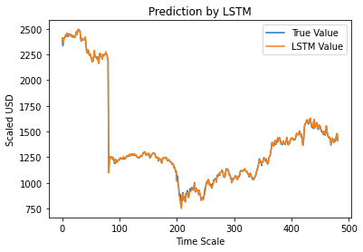

```python
#Predicted vs True Adj Close Value – LSTM
plt.plot(y_test, label='True Value')
plt.plot(y_pred, label='LSTM Value')
plt.title("Prediction by LSTM")
plt.xlabel('Time Scale')
plt.ylabel('Scaled USD')
plt.legend()
plt.show()
```

```python
x_scaled_transf.head()
```

|  | P1 | P2 | P3 | P4 | P5 | Date |
| --- | --- | --- | --- | --- | --- | --- |
| 0 | -0.856094 | -0.013702 | -0.004511 | -0.000980 | 0.001516 | 2000-01-03 |
| 1 | -0.846492 | -0.012379 | -0.002583 | -0.000665 | -0.002812 | 2000-01-04 |
| 2 | -0.852530 | -0.012476 | 0.001545 | -0.000265 | -0.000110 | 2000-01-05 |
| 3 | -0.854614 | -0.013216 | -0.000724 | -0.001035 | 0.000965 | 2000-01-06 |
| 4 | -0.855715 | -0.013192 | 0.000074 | 0.001196 | 0.002353 | 2000-01-07 |

```python
#!pip install autokeras
```

```python
print(x_scaled_transf.shape)
x_scaled_transf=x_scaled_transf.drop(['Date'],axis=1)
```

```
(5306, 6)
```

```python
x_scaled_transf.head()
```

|  | P1 | P2 | P3 | P4 | P5 |
| --- | --- | --- | --- | --- | --- |
| 0 | -0.856094 | -0.013702 | -0.004511 | -0.000980 | 0.001516 |
| 1 | -0.846492 | -0.012379 | -0.002583 | -0.000665 | -0.002812 |
| 2 | -0.852530 | -0.012476 | 0.001545 | -0.000265 | -0.000110 |
| 3 | -0.854614 | -0.013216 | -0.000724 | -0.001035 | 0.000965 |
| 4 | -0.855715 | -0.013192 | 0.000074 | 0.001196 | 0.002353 |

```python
from autokeras import StructuredDataRegressor
from sklearn.preprocessing import LabelEncoder
from sklearn.model_selection import train_test_split
```

```python
# basic data preparation
X = x_scaled_transf.astype('float32')
y = output_var.astype('float32')
```

```python
# separate into train and test sets
X_train, X_test, y_train, y_test = train_test_split(X, y, test_size=0.20, random_state=1)
print(X_train.shape, X_test.shape, y_train.shape, y_test.shape)
```

```
(4244, 5) (1062, 5) (4244, 1) (1062, 1)
```

```python
# Initialize the StructuredDataRegressor
reg = StructuredDataRegressor(max_trials=15,overwrite=True,metrics=['mae'])
# Search for the best model.
reg.fit(X_train.to_numpy(),y_train.to_numpy(), validation_split=0.2,epochs=100, verbose=0)
```

```
INFO:tensorflow:Oracle triggered exit
INFO:tensorflow:Assets written to: ./structured_data_regressor/best_model/assets
```

```
<keras.callbacks.History at 0x7f5a98f4b490>
```

```python
predicted = reg.predict(X_test)
```

```python
# evaluate the model
loss, acc =reg.evaluate(X_train,y_train, verbose=0)
print('Accuracy: %.3f' % acc)
print('loss: %.3f' % loss)
```

```
Accuracy: 2.505
loss: 16.418
```

**EVALUATE MODEL PERFORMANCE**

**MEAN ABSOLUTE ERROR (MAE) FOR TEST DATA**

```python
from sklearn.metrics import mean_absolute_error
print("MEAN ABSOLUTE ERROR (MAE) FOR TEST DATA IS")
np.round(mean_absolute_error(predicted,y_test),3)
```

```
MEAN ABSOLUTE ERROR (MAE) FOR TEST DATA IS
```

```
2.453
```

**MEAN SQUARE ERROR (MSE) FOR TEST DATA**

```python
from sklearn.metrics import mean_squared_error
print("MEAN SQUARE ERROR (MSE) FOR TEST DATA IS")
mse=np.round(mean_squared_error(predicted,y_test),3)
mse
```

```
MEAN SQUARE ERROR (MSE) FOR TEST DATA IS
```

```
16.208
```

**ROOT MEAN SQUARE ERROR (MSE) FOR TEST DATA**

```python
import math
math.sqrt(mse)
```

```
4.025916067568407
```

**MEDIAN ABSOLUTE ERROR (MAE) FOR TEST DATA**

```python
from sklearn.metrics import median_absolute_error
print("MEDIAN ABSOLUTE ERROR (MAE) FOR TEST DATA IS")
np.round(median_absolute_error(predicted,y_test),3)
```

```
MEDIAN ABSOLUTE ERROR (MAE) FOR TEST DATA IS
```

```
1.477
```

**R-square FOR TEST DATA**

```python
from sklearn.metrics import r2_score
print("R-square FOR TEST DATA IS")
#np.round(r2_score(y_test,y_pred),3)
np.round(r2_score(predicted,y_test),3)
```

```
R-square FOR TEST DATA IS
```

```
1.0
```

**Mean Absolute Percentage Error FOR TEST DATA**

```python
print("MAPE FOR TEST DATA IS")
mape1 = np.mean(np.abs((y_test - predicted)/y_test))*100
np.round(mape1,3)
```

```
MAPE FOR TEST DATA IS
```

```
Close    0.298
dtype: float32
```

**Get the best performing model and Summarize the loaded model**

```python
keras_model = reg.export_model()
keras_model.summary()
```

```
Model: "model"
_________________________________________________________________
 Layer (type)                Output Shape              Param #
=================================================================
 input_1 (InputLayer)        [(None, 5)]               0

 multi_category_encoding (Mu  (None, 5)                0
 ltiCategoryEncoding)

 dense (Dense)               (None, 256)               1536

 re_lu (ReLU)                (None, 256)               0

 dense_1 (Dense)             (None, 16)                4112

 re_lu_1 (ReLU)              (None, 16)                0

 regression_head_1 (Dense)   (None, 1)                 17

=================================================================
Total params: 5,665
Trainable params: 5,665
Non-trainable params: 0
_________________________________________________________________
```

**View the visual representation of the model**

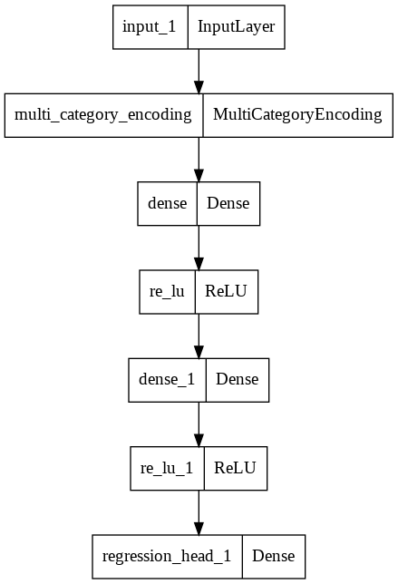

```python
import tensorflow as tf
tf.keras.utils.plot_model
plot_model(keras_model)
```

```python
!jupyter nbconvert StockMarketPrediction_PCA.ipynb
```

```
[NbConvertApp] Converting notebook StockMarketPrediction_PCA.ipynb to html
[NbConvertApp] Writing 543658 bytes to StockMarketPrediction_PCA.html
```